# Risk Factor Analysis

## Outcome Variable

**Outcome Variable:** wast_rec90d

## Predictor Variables

**Intervention Variable:** enstunt

**Adjustment Set:**

- arm
- sex
- W_mage
- meducyrs
- feducyrs
- vagbrth
- single
- brthmon
- W_parity
- delta_W_mage
- delta_meducyrs
- delta_feducyrs
- delta_vagbrth
- delta_single
- delta_brthmon
- delta_W_parity

## Stratifying Variables

The analysis was stratified on these variable(s):

- agecat
- studyid
- country

## Data Summary

| agecat | studyid | country | enstunt | wast_rec90d | n_cell | n |
| --- | --- | --- | --- | --- | --- | --- |
| 0-24 months | CMC-V-BCS-2002 | INDIA | 0 | 0 | 88 | 324 |
| 0-24 months | CMC-V-BCS-2002 | INDIA | 0 | 1 | 159 | 324 |
| 0-24 months | CMC-V-BCS-2002 | INDIA | 1 | 0 | 32 | 324 |
| 0-24 months | CMC-V-BCS-2002 | INDIA | 1 | 1 | 45 | 324 |
| 0-24 months | CMIN | BANGLADESH | 0 | 0 | 40 | 190 |
| 0-24 months | CMIN | BANGLADESH | 0 | 1 | 68 | 190 |
| 0-24 months | CMIN | BANGLADESH | 1 | 0 | 40 | 190 |
| 0-24 months | CMIN | BANGLADESH | 1 | 1 | 42 | 190 |
| 0-24 months | COHORTS | GUATEMALA | 0 | 0 | 141 | 381 |
| 0-24 months | COHORTS | GUATEMALA | 0 | 1 | 167 | 381 |
| 0-24 months | COHORTS | GUATEMALA | 1 | 0 | 72 | 381 |
| 0-24 months | COHORTS | GUATEMALA | 1 | 1 | 1 | 381 |
| 0-24 months | COHORTS | INDIA | 0 | 0 | 1674 | 2663 |
| 0-24 months | COHORTS | INDIA | 0 | 1 | 622 | 2663 |
| 0-24 months | COHORTS | INDIA | 1 | 0 | 345 | 2663 |
| 0-24 months | COHORTS | INDIA | 1 | 1 | 22 | 2663 |
| 0-24 months | COHORTS | PHILIPPINES | 0 | 0 | 604 | 1689 |
| 0-24 months | COHORTS | PHILIPPINES | 0 | 1 | 964 | 1689 |
| 0-24 months | COHORTS | PHILIPPINES | 1 | 0 | 60 | 1689 |
| 0-24 months | COHORTS | PHILIPPINES | 1 | 1 | 61 | 1689 |
| 0-24 months | CONTENT | PERU | 0 | 0 | 1 | 7 |
| 0-24 months | CONTENT | PERU | 0 | 1 | 5 | 7 |
| 0-24 months | CONTENT | PERU | 1 | 0 | 0 | 7 |
| 0-24 months | CONTENT | PERU | 1 | 1 | 1 | 7 |
| 0-24 months | EE | PAKISTAN | 0 | 0 | 77 | 323 |
| 0-24 months | EE | PAKISTAN | 0 | 1 | 95 | 323 |
| 0-24 months | EE | PAKISTAN | 1 | 0 | 83 | 323 |
| 0-24 months | EE | PAKISTAN | 1 | 1 | 68 | 323 |
| 0-24 months | GMS-Nepal | NEPAL | 0 | 0 | 249 | 643 |
| 0-24 months | GMS-Nepal | NEPAL | 0 | 1 | 300 | 643 |

[output cut: 338 more lines]

The following strata were considered:

- agecat: 0-24 months, studyid: CMC-V-BCS-2002, country: INDIA
- agecat: 0-24 months, studyid: CMIN, country: BANGLADESH
- agecat: 0-24 months, studyid: COHORTS, country: GUATEMALA
- agecat: 0-24 months, studyid: COHORTS, country: INDIA
- agecat: 0-24 months, studyid: COHORTS, country: PHILIPPINES
- agecat: 0-24 months, studyid: CONTENT, country: PERU
- agecat: 0-24 months, studyid: EE, country: PAKISTAN
- agecat: 0-24 months, studyid: GMS-Nepal, country: NEPAL
- agecat: 0-24 months, studyid: Guatemala BSC, country: GUATEMALA
- agecat: 0-24 months, studyid: iLiNS-Zinc, country: BURKINA FASO
- agecat: 0-24 months, studyid: IRC, country: INDIA
- agecat: 0-24 months, studyid: JiVitA-3, country: BANGLADESH
- agecat: 0-24 months, studyid: JiVitA-4, country: BANGLADESH
- agecat: 0-24 months, studyid: Keneba, country: GAMBIA
- agecat: 0-24 months, studyid: LCNI-5, country: MALAWI
- agecat: 0-24 months, studyid: MAL-ED, country: BANGLADESH
- agecat: 0-24 months, studyid: MAL-ED, country: BRAZIL
- agecat: 0-24 months, studyid: MAL-ED, country: INDIA
- agecat: 0-24 months, studyid: MAL-ED, country: NEPAL
- agecat: 0-24 months, studyid: MAL-ED, country: PERU
- agecat: 0-24 months, studyid: MAL-ED, country: SOUTH AFRICA
- agecat: 0-24 months, studyid: MAL-ED, country: TANZANIA, UNITED REPUBLIC OF
- agecat: 0-24 months, studyid: NIH-Birth, country: BANGLADESH
- agecat: 0-24 months, studyid: NIH-Crypto, country: BANGLADESH
- agecat: 0-24 months, studyid: PROBIT, country: BELARUS
- agecat: 0-24 months, studyid: PROVIDE, country: BANGLADESH
- agecat: 0-24 months, studyid: ResPak, country: PAKISTAN
- agecat: 0-24 months, studyid: SAS-CompFeed, country: INDIA
- agecat: 0-24 months, studyid: SAS-FoodSuppl, country: INDIA
- agecat: 0-24 months, studyid: TanzaniaChild2, country: TANZANIA, UNITED REPUBLIC OF
- agecat: 0-24 months, studyid: ZVITAMBO, country: ZIMBABWE
- agecat: 0-6 months, studyid: CMC-V-BCS-2002, country: INDIA
- agecat: 0-6 months, studyid: CMIN, country: BANGLADESH
- agecat: 0-6 months, studyid: COHORTS, country: GUATEMALA
- agecat: 0-6 months, studyid: COHORTS, country: INDIA
- agecat: 0-6 months, studyid: COHORTS, country: PHILIPPINES
- agecat: 0-6 months, studyid: CONTENT, country: PERU
- agecat: 0-6 months, studyid: EE, country: PAKISTAN
- agecat: 0-6 months, studyid: GMS-Nepal, country: NEPAL
- agecat: 0-6 months, studyid: Guatemala BSC, country: GUATEMALA
- agecat: 0-6 months, studyid: IRC, country: INDIA
- agecat: 0-6 months, studyid: JiVitA-3, country: BANGLADESH
- agecat: 0-6 months, studyid: JiVitA-4, country: BANGLADESH
- agecat: 0-6 months, studyid: Keneba, country: GAMBIA
- agecat: 0-6 months, studyid: LCNI-5, country: MALAWI
- agecat: 0-6 months, studyid: MAL-ED, country: BANGLADESH
- agecat: 0-6 months, studyid: MAL-ED, country: BRAZIL
- agecat: 0-6 months, studyid: MAL-ED, country: INDIA
- agecat: 0-6 months, studyid: MAL-ED, country: NEPAL
- agecat: 0-6 months, studyid: MAL-ED, country: PERU
- agecat: 0-6 months, studyid: MAL-ED, country: SOUTH AFRICA
- agecat: 0-6 months, studyid: MAL-ED, country: TANZANIA, UNITED REPUBLIC OF
- agecat: 0-6 months, studyid: NIH-Birth, country: BANGLADESH
- agecat: 0-6 months, studyid: NIH-Crypto, country: BANGLADESH
- agecat: 0-6 months, studyid: PROBIT, country: BELARUS
- agecat: 0-6 months, studyid: PROVIDE, country: BANGLADESH
- agecat: 0-6 months, studyid: ResPak, country: PAKISTAN
- agecat: 0-6 months, studyid: SAS-CompFeed, country: INDIA
- agecat: 0-6 months, studyid: SAS-FoodSuppl, country: INDIA
- agecat: 0-6 months, studyid: TanzaniaChild2, country: TANZANIA, UNITED REPUBLIC OF
- agecat: 0-6 months, studyid: ZVITAMBO, country: ZIMBABWE
- agecat: 6-24 months, studyid: CMC-V-BCS-2002, country: INDIA
- agecat: 6-24 months, studyid: CMIN, country: BANGLADESH
- agecat: 6-24 months, studyid: COHORTS, country: GUATEMALA
- agecat: 6-24 months, studyid: COHORTS, country: INDIA
- agecat: 6-24 months, studyid: COHORTS, country: PHILIPPINES
- agecat: 6-24 months, studyid: CONTENT, country: PERU
- agecat: 6-24 months, studyid: EE, country: PAKISTAN
- agecat: 6-24 months, studyid: GMS-Nepal, country: NEPAL
- agecat: 6-24 months, studyid: Guatemala BSC, country: GUATEMALA
- agecat: 6-24 months, studyid: iLiNS-Zinc, country: BURKINA FASO
- agecat: 6-24 months, studyid: IRC, country: INDIA
- agecat: 6-24 months, studyid: JiVitA-3, country: BANGLADESH
- agecat: 6-24 months, studyid: JiVitA-4, country: BANGLADESH
- agecat: 6-24 months, studyid: Keneba, country: GAMBIA
- agecat: 6-24 months, studyid: LCNI-5, country: MALAWI
- agecat: 6-24 months, studyid: MAL-ED, country: BANGLADESH
- agecat: 6-24 months, studyid: MAL-ED, country: BRAZIL
- agecat: 6-24 months, studyid: MAL-ED, country: INDIA
- agecat: 6-24 months, studyid: MAL-ED, country: NEPAL
- agecat: 6-24 months, studyid: MAL-ED, country: PERU
- agecat: 6-24 months, studyid: MAL-ED, country: SOUTH AFRICA
- agecat: 6-24 months, studyid: MAL-ED, country: TANZANIA, UNITED REPUBLIC OF
- agecat: 6-24 months, studyid: NIH-Birth, country: BANGLADESH
- agecat: 6-24 months, studyid: NIH-Crypto, country: BANGLADESH
- agecat: 6-24 months, studyid: PROBIT, country: BELARUS
- agecat: 6-24 months, studyid: PROVIDE, country: BANGLADESH
- agecat: 6-24 months, studyid: ResPak, country: PAKISTAN
- agecat: 6-24 months, studyid: SAS-CompFeed, country: INDIA
- agecat: 6-24 months, studyid: SAS-FoodSuppl, country: INDIA
- agecat: 6-24 months, studyid: TanzaniaChild2, country: TANZANIA, UNITED REPUBLIC OF
- agecat: 6-24 months, studyid: ZVITAMBO, country: ZIMBABWE

### Dropped Strata

Some strata were dropped due to rare outcomes:

- agecat: 0-24 months, studyid: COHORTS, country: GUATEMALA
- agecat: 0-24 months, studyid: CONTENT, country: PERU
- agecat: 0-24 months, studyid: MAL-ED, country: BRAZIL
- agecat: 0-24 months, studyid: MAL-ED, country: NEPAL
- agecat: 0-24 months, studyid: MAL-ED, country: PERU
- agecat: 0-24 months, studyid: MAL-ED, country: SOUTH AFRICA
- agecat: 0-24 months, studyid: MAL-ED, country: TANZANIA, UNITED REPUBLIC OF
- agecat: 0-24 months, studyid: PROBIT, country: BELARUS
- agecat: 0-24 months, studyid: SAS-FoodSuppl, country: INDIA
- agecat: 0-6 months, studyid: COHORTS, country: GUATEMALA
- agecat: 0-6 months, studyid: CONTENT, country: PERU
- agecat: 0-6 months, studyid: Guatemala BSC, country: GUATEMALA
- agecat: 0-6 months, studyid: LCNI-5, country: MALAWI
- agecat: 0-6 months, studyid: MAL-ED, country: BANGLADESH
- agecat: 0-6 months, studyid: MAL-ED, country: BRAZIL
- agecat: 0-6 months, studyid: MAL-ED, country: INDIA
- agecat: 0-6 months, studyid: MAL-ED, country: NEPAL
- agecat: 0-6 months, studyid: MAL-ED, country: PERU
- agecat: 0-6 months, studyid: MAL-ED, country: SOUTH AFRICA
- agecat: 0-6 months, studyid: MAL-ED, country: TANZANIA, UNITED REPUBLIC OF
- agecat: 0-6 months, studyid: NIH-Crypto, country: BANGLADESH
- agecat: 0-6 months, studyid: PROBIT, country: BELARUS
- agecat: 0-6 months, studyid: SAS-FoodSuppl, country: INDIA
- agecat: 0-6 months, studyid: TanzaniaChild2, country: TANZANIA, UNITED REPUBLIC OF
- agecat: 6-24 months, studyid: COHORTS, country: GUATEMALA
- agecat: 6-24 months, studyid: COHORTS, country: INDIA
- agecat: 6-24 months, studyid: CONTENT, country: PERU
- agecat: 6-24 months, studyid: JiVitA-3, country: BANGLADESH
- agecat: 6-24 months, studyid: MAL-ED, country: BRAZIL
- agecat: 6-24 months, studyid: MAL-ED, country: NEPAL
- agecat: 6-24 months, studyid: MAL-ED, country: PERU
- agecat: 6-24 months, studyid: MAL-ED, country: SOUTH AFRICA
- agecat: 6-24 months, studyid: MAL-ED, country: TANZANIA, UNITED REPUBLIC OF
- agecat: 6-24 months, studyid: NIH-Crypto, country: BANGLADESH
- agecat: 6-24 months, studyid: PROBIT, country: BELARUS
- agecat: 6-24 months, studyid: SAS-FoodSuppl, country: INDIA

## Methods Detail

We’re interested in the causal parameters $E[Y_a]$ for all values of $a \in \mathcal{A}$. These parameters represent the mean outcome if, possibly contrary to fact, we intervened to set all units to have $A=a$. Under the randomization and positivity assumptions, these are identified by the statistical parameters $\psi_a=E_W[E_{Y|A,W}(Y|A=a,W)]$. In addition, we’re interested in the mean of $Y$, $E[Y]$ under no intervention (the observed mean). We will estimate these parameters by using SuperLearner to fit the relevant likelihood factors – $E_{Y|A,W}(Y|A=a,W)$ and $p(A=a|W)$, and then updating our likelihood fit using a joint TMLE.

For unadjusted analyses ($W=\{\}$), initial likelihoods were estimated using Lrnr_glm to estimate the simple $E(Y|A)$ and Lrnr_mean to estimate $p(A)$. For adjusted analyses, a small library containing Lrnr_glmnet, Lrnr_xgboost, and Lrnr_mean was used.

Having estimated these parameters, we will then use the delta method to estimate relative risks and attributable risks relative to a prespecified baseline level of $A$.

# Results Detail

## Results Plots

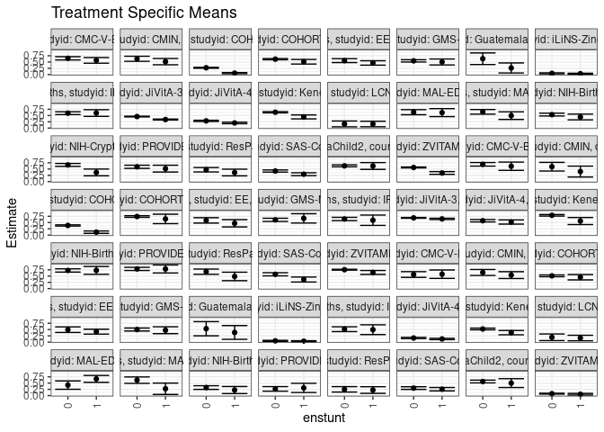

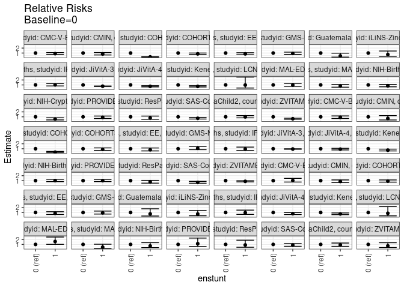

[figure not shown]

[figure not shown]

## Results Table

### Parameter: TSM

| agecat | studyid | country | intervention_level | baseline_level | estimate | ci_lower | ci_upper |
| --- | --- | --- | --- | --- | --- | --- | --- |
| 0-24 months | CMC-V-BCS-2002 | INDIA | 0 | NA | 0.6473184 | 0.5824814 | 0.7121554 |
| 0-24 months | CMC-V-BCS-2002 | INDIA | 1 | NA | 0.5662002 | 0.4525008 | 0.6798995 |
| 0-24 months | CMIN | BANGLADESH | 0 | NA | 0.6302250 | 0.5299060 | 0.7305441 |
| 0-24 months | CMIN | BANGLADESH | 1 | NA | 0.5160567 | 0.3904994 | 0.6416141 |
| 0-24 months | COHORTS | INDIA | 0 | NA | 0.2717720 | 0.2534784 | 0.2900655 |
| 0-24 months | COHORTS | INDIA | 1 | NA | 0.0574878 | 0.0348019 | 0.0801738 |
| 0-24 months | COHORTS | PHILIPPINES | 0 | NA | 0.6142334 | 0.5888902 | 0.6395767 |
| 0-24 months | COHORTS | PHILIPPINES | 1 | NA | 0.5111921 | 0.4193106 | 0.6030737 |
| 0-24 months | EE | PAKISTAN | 0 | NA | 0.5563336 | 0.4780157 | 0.6346515 |
| 0-24 months | EE | PAKISTAN | 1 | NA | 0.4633193 | 0.3751138 | 0.5515248 |
| 0-24 months | GMS-Nepal | NEPAL | 0 | NA | 0.5462474 | 0.5007763 | 0.5917186 |
| 0-24 months | GMS-Nepal | NEPAL | 1 | NA | 0.5020388 | 0.3832952 | 0.6207825 |
| 0-24 months | Guatemala BSC | GUATEMALA | 0 | NA | 0.6315789 | 0.4004047 | 0.8627532 |
| 0-24 months | Guatemala BSC | GUATEMALA | 1 | NA | 0.2631579 | 0.0627483 | 0.4635675 |
| 0-24 months | iLiNS-Zinc | BURKINA FASO | 0 | NA | 0.0492838 | 0.0298906 | 0.0686769 |
| 0-24 months | iLiNS-Zinc | BURKINA FASO | 1 | NA | 0.0343251 | 0.0143389 | 0.0543113 |
| 0-24 months | IRC | INDIA | 0 | NA | 0.5947508 | 0.5385811 | 0.6509205 |
| 0-24 months | IRC | INDIA | 1 | NA | 0.5995270 | 0.4663717 | 0.7326822 |
| 0-24 months | JiVitA-3 | BANGLADESH | 0 | NA | 0.4593376 | 0.4456909 | 0.4729843 |
| 0-24 months | JiVitA-3 | BANGLADESH | 1 | NA | 0.3400899 | 0.3210127 | 0.3591672 |
| 0-24 months | JiVitA-4 | BANGLADESH | 0 | NA | 0.2871905 | 0.2622598 | 0.3121211 |
| 0-24 months | JiVitA-4 | BANGLADESH | 1 | NA | 0.2055508 | 0.1760423 | 0.2350593 |
| 0-24 months | Keneba | GAMBIA | 0 | NA | 0.6310190 | 0.6060526 | 0.6559854 |
| 0-24 months | Keneba | GAMBIA | 1 | NA | 0.4454865 | 0.3664407 | 0.5245323 |
| 0-24 months | LCNI-5 | MALAWI | 0 | NA | 0.1666667 | 0.0503410 | 0.2829923 |
| 0-24 months | LCNI-5 | MALAWI | 1 | NA | 0.1632653 | 0.0532454 | 0.2732852 |
| 0-24 months | MAL-ED | BANGLADESH | 0 | NA | 0.6337090 | 0.5324959 | 0.7349221 |
| 0-24 months | MAL-ED | BANGLADESH | 1 | NA | 0.6158688 | 0.4566713 | 0.7750663 |
| 0-24 months | MAL-ED | INDIA | 0 | NA | 0.6472802 | 0.5552291 | 0.7393313 |
| 0-24 months | MAL-ED | INDIA | 1 | NA | 0.4964153 | 0.3437908 | 0.6490398 |

[output cut: 82 more lines]

### Parameter: E(Y)

| agecat | studyid | country | intervention_level | baseline_level | estimate | ci_lower | ci_upper |
| --- | --- | --- | --- | --- | --- | --- | --- |
| 0-24 months | CMC-V-BCS-2002 | INDIA | NA | NA | 0.6296296 | 0.5734927 | 0.6857666 |
| 0-24 months | CMIN | BANGLADESH | NA | NA | 0.5789474 | 0.5004470 | 0.6574477 |
| 0-24 months | COHORTS | INDIA | NA | NA | 0.2418325 | 0.2254819 | 0.2581831 |
| 0-24 months | COHORTS | PHILIPPINES | NA | NA | 0.6068680 | 0.5823645 | 0.6313715 |
| 0-24 months | EE | PAKISTAN | NA | NA | 0.5046440 | 0.4456009 | 0.5636870 |
| 0-24 months | GMS-Nepal | NEPAL | NA | NA | 0.5396579 | 0.4973524 | 0.5819633 |
| 0-24 months | Guatemala BSC | GUATEMALA | NA | NA | 0.4473684 | 0.2760904 | 0.6186464 |
| 0-24 months | iLiNS-Zinc | BURKINA FASO | NA | NA | 0.0439024 | 0.0298653 | 0.0579396 |
| 0-24 months | IRC | INDIA | NA | NA | 0.5898734 | 0.5376978 | 0.6420491 |
| 0-24 months | JiVitA-3 | BANGLADESH | NA | NA | 0.4221371 | 0.4110175 | 0.4332567 |
| 0-24 months | JiVitA-4 | BANGLADESH | NA | NA | 0.2585790 | 0.2392503 | 0.2779077 |
| 0-24 months | Keneba | GAMBIA | NA | NA | 0.6105033 | 0.5863646 | 0.6346419 |
| 0-24 months | LCNI-5 | MALAWI | NA | NA | 0.1645570 | 0.0832789 | 0.2458350 |
| 0-24 months | MAL-ED | BANGLADESH | NA | NA | 0.6451613 | 0.5593015 | 0.7310211 |
| 0-24 months | MAL-ED | INDIA | NA | NA | 0.6077348 | 0.5286689 | 0.6868008 |
| 0-24 months | NIH-Birth | BANGLADESH | NA | NA | 0.5201900 | 0.4695846 | 0.5707955 |
| 0-24 months | NIH-Crypto | BANGLADESH | NA | NA | 0.6225806 | 0.5684562 | 0.6767051 |
| 0-24 months | PROVIDE | BANGLADESH | NA | NA | 0.5811688 | 0.5245443 | 0.6377934 |
| 0-24 months | ResPak | PAKISTAN | NA | NA | 0.4509804 | 0.3794254 | 0.5225353 |
| 0-24 months | SAS-CompFeed | INDIA | NA | NA | 0.3808354 | 0.3457640 | 0.4159068 |
| 0-24 months | TanzaniaChild2 | TANZANIA, UNITED REPUBLIC OF | NA | NA | 0.6269285 | 0.5892870 | 0.6645700 |
| 0-24 months | ZVITAMBO | ZIMBABWE | NA | NA | 0.5432918 | 0.5268968 | 0.5596869 |
| 0-6 months | CMC-V-BCS-2002 | INDIA | NA | NA | 0.6716418 | 0.6057305 | 0.7375531 |
| 0-6 months | CMIN | BANGLADESH | NA | NA | 0.5192308 | 0.3806687 | 0.6577929 |
| 0-6 months | COHORTS | INDIA | NA | NA | 0.3585746 | 0.3363886 | 0.3807606 |
| 0-6 months | COHORTS | PHILIPPINES | NA | NA | 0.7367021 | 0.7051294 | 0.7682749 |
| 0-6 months | EE | PAKISTAN | NA | NA | 0.5669291 | 0.4800274 | 0.6538309 |
| 0-6 months | GMS-Nepal | NEPAL | NA | NA | 0.6045627 | 0.5449300 | 0.6641955 |
| 0-6 months | IRC | INDIA | NA | NA | 0.6375000 | 0.5751450 | 0.6998550 |
| 0-6 months | JiVitA-3 | BANGLADESH | NA | NA | 0.6751162 | 0.6617750 | 0.6884574 |
| 0-6 months | JiVitA-4 | BANGLADESH | NA | NA | 0.5587703 | 0.5173487 | 0.6001920 |
| 0-6 months | Keneba | GAMBIA | NA | NA | 0.7720994 | 0.7419223 | 0.8022766 |
| 0-6 months | NIH-Birth | BANGLADESH | NA | NA | 0.7130045 | 0.6535890 | 0.7724200 |
| 0-6 months | PROVIDE | BANGLADESH | NA | NA | 0.7837838 | 0.7252863 | 0.8422812 |
| 0-6 months | ResPak | PAKISTAN | NA | NA | 0.6194690 | 0.5292383 | 0.7096997 |
| 0-6 months | SAS-CompFeed | INDIA | NA | NA | 0.5131965 | 0.4596632 | 0.5667297 |
| 0-6 months | ZVITAMBO | ZIMBABWE | NA | NA | 0.7475189 | 0.7305656 | 0.7644721 |
| 6-24 months | CMC-V-BCS-2002 | INDIA | NA | NA | 0.5609756 | 0.4682842 | 0.6536670 |
| 6-24 months | CMIN | BANGLADESH | NA | NA | 0.6014493 | 0.5131344 | 0.6897641 |
| 6-24 months | COHORTS | PHILIPPINES | NA | NA | 0.5026681 | 0.4688378 | 0.5364984 |
| 6-24 months | EE | PAKISTAN | NA | NA | 0.4642857 | 0.3910729 | 0.5374985 |
| 6-24 months | GMS-Nepal | NEPAL | NA | NA | 0.4947368 | 0.4401559 | 0.5493178 |
| 6-24 months | Guatemala BSC | GUATEMALA | NA | NA | 0.4642857 | 0.2621560 | 0.6664155 |
| 6-24 months | iLiNS-Zinc | BURKINA FASO | NA | NA | 0.0439024 | 0.0298653 | 0.0579396 |
| 6-24 months | IRC | INDIA | NA | NA | 0.5161290 | 0.4322562 | 0.6000019 |
| 6-24 months | JiVitA-4 | BANGLADESH | NA | NA | 0.1490765 | 0.1314900 | 0.1666630 |
| 6-24 months | Keneba | GAMBIA | NA | NA | 0.5045290 | 0.4730969 | 0.5359611 |
| 6-24 months | LCNI-5 | MALAWI | NA | NA | 0.1733333 | 0.0886479 | 0.2580188 |
| 6-24 months | MAL-ED | BANGLADESH | NA | NA | 0.4918033 | 0.3610932 | 0.6225134 |
| 6-24 months | MAL-ED | INDIA | NA | NA | 0.5368421 | 0.4223932 | 0.6512910 |
| 6-24 months | NIH-Birth | BANGLADESH | NA | NA | 0.3030303 | 0.2377927 | 0.3682679 |
| 6-24 months | PROVIDE | BANGLADESH | NA | NA | 0.2764228 | 0.1950773 | 0.3577682 |
| 6-24 months | ResPak | PAKISTAN | NA | NA | 0.2417582 | 0.1565924 | 0.3269241 |
| 6-24 months | SAS-CompFeed | INDIA | NA | NA | 0.2854123 | 0.2436284 | 0.3271961 |
| 6-24 months | TanzaniaChild2 | TANZANIA, UNITED REPUBLIC OF | NA | NA | 0.5576408 | 0.5054408 | 0.6098407 |
| 6-24 months | ZVITAMBO | ZIMBABWE | NA | NA | 0.0739051 | 0.0584895 | 0.0893208 |

### Parameter: RR

| agecat | studyid | country | intervention_level | baseline_level | estimate | ci_lower | ci_upper |
| --- | --- | --- | --- | --- | --- | --- | --- |
| 0-24 months | CMC-V-BCS-2002 | INDIA | 0 | 0 | 1.0000000 | 1.0000000 | 1.0000000 |
| 0-24 months | CMC-V-BCS-2002 | INDIA | 1 | 0 | 0.8746857 | 0.6996615 | 1.0934933 |
| 0-24 months | CMIN | BANGLADESH | 0 | 0 | 1.0000000 | 1.0000000 | 1.0000000 |
| 0-24 months | CMIN | BANGLADESH | 1 | 0 | 0.8188452 | 0.6118874 | 1.0958019 |
| 0-24 months | COHORTS | INDIA | 0 | 0 | 1.0000000 | 1.0000000 | 1.0000000 |
| 0-24 months | COHORTS | INDIA | 1 | 0 | 0.2115297 | 0.1417510 | 0.3156576 |
| 0-24 months | COHORTS | PHILIPPINES | 0 | 0 | 1.0000000 | 1.0000000 | 1.0000000 |
| 0-24 months | COHORTS | PHILIPPINES | 1 | 0 | 0.8322441 | 0.6921215 | 1.0007350 |
| 0-24 months | EE | PAKISTAN | 0 | 0 | 1.0000000 | 1.0000000 | 1.0000000 |
| 0-24 months | EE | PAKISTAN | 1 | 0 | 0.8328084 | 0.6571506 | 1.0554199 |
| 0-24 months | GMS-Nepal | NEPAL | 0 | 0 | 1.0000000 | 1.0000000 | 1.0000000 |
| 0-24 months | GMS-Nepal | NEPAL | 1 | 0 | 0.9190686 | 0.7150735 | 1.1812591 |
| 0-24 months | Guatemala BSC | GUATEMALA | 0 | 0 | 1.0000000 | 1.0000000 | 1.0000000 |
| 0-24 months | Guatemala BSC | GUATEMALA | 1 | 0 | 0.4166667 | 0.1790304 | 0.9697297 |
| 0-24 months | iLiNS-Zinc | BURKINA FASO | 0 | 0 | 1.0000000 | 1.0000000 | 1.0000000 |
| 0-24 months | iLiNS-Zinc | BURKINA FASO | 1 | 0 | 0.6964796 | 0.3447818 | 1.4069301 |
| 0-24 months | IRC | INDIA | 0 | 0 | 1.0000000 | 1.0000000 | 1.0000000 |
| 0-24 months | IRC | INDIA | 1 | 0 | 1.0080306 | 0.7916099 | 1.2836191 |
| 0-24 months | JiVitA-3 | BANGLADESH | 0 | 0 | 1.0000000 | 1.0000000 | 1.0000000 |
| 0-24 months | JiVitA-3 | BANGLADESH | 1 | 0 | 0.7403921 | 0.6949191 | 0.7888408 |
| 0-24 months | JiVitA-4 | BANGLADESH | 0 | 0 | 1.0000000 | 1.0000000 | 1.0000000 |
| 0-24 months | JiVitA-4 | BANGLADESH | 1 | 0 | 0.7157299 | 0.6054472 | 0.8461007 |
| 0-24 months | Keneba | GAMBIA | 0 | 0 | 1.0000000 | 1.0000000 | 1.0000000 |
| 0-24 months | Keneba | GAMBIA | 1 | 0 | 0.7059795 | 0.5888972 | 0.8463398 |
| 0-24 months | LCNI-5 | MALAWI | 0 | 0 | 1.0000000 | 1.0000000 | 1.0000000 |
| 0-24 months | LCNI-5 | MALAWI | 1 | 0 | 0.9795918 | 0.3712732 | 2.5846201 |
| 0-24 months | MAL-ED | BANGLADESH | 0 | 0 | 1.0000000 | 1.0000000 | 1.0000000 |
| 0-24 months | MAL-ED | BANGLADESH | 1 | 0 | 0.9718481 | 0.7161369 | 1.3188661 |
| 0-24 months | MAL-ED | INDIA | 0 | 0 | 1.0000000 | 1.0000000 | 1.0000000 |
| 0-24 months | MAL-ED | INDIA | 1 | 0 | 0.7669249 | 0.5469070 | 1.0754549 |

[output cut: 82 more lines]

### Parameter: PAR

| agecat | studyid | country | intervention_level | baseline_level | estimate | ci_lower | ci_upper |
| --- | --- | --- | --- | --- | --- | --- | --- |
| 0-24 months | CMC-V-BCS-2002 | INDIA | 0 | NA | -0.0176888 | -0.0479830 | 0.0126055 |
| 0-24 months | CMIN | BANGLADESH | 0 | NA | -0.0512777 | -0.1214531 | 0.0188978 |
| 0-24 months | COHORTS | INDIA | 0 | NA | -0.0299394 | -0.0350393 | -0.0248395 |
| 0-24 months | COHORTS | PHILIPPINES | 0 | NA | -0.0073655 | -0.0143060 | -0.0004249 |
| 0-24 months | EE | PAKISTAN | 0 | NA | -0.0516896 | -0.1074614 | 0.0040821 |
| 0-24 months | GMS-Nepal | NEPAL | 0 | NA | -0.0065896 | -0.0251220 | 0.0119429 |
| 0-24 months | Guatemala BSC | GUATEMALA | 0 | NA | -0.1842105 | -0.3548689 | -0.0135521 |
| 0-24 months | iLiNS-Zinc | BURKINA FASO | 0 | NA | -0.0053813 | -0.0169211 | 0.0061584 |
| 0-24 months | IRC | INDIA | 0 | NA | -0.0048774 | -0.0259504 | 0.0161957 |
| 0-24 months | JiVitA-3 | BANGLADESH | 0 | NA | -0.0372005 | -0.0447548 | -0.0296462 |
| 0-24 months | JiVitA-4 | BANGLADESH | 0 | NA | -0.0286115 | -0.0425082 | -0.0147147 |
| 0-24 months | Keneba | GAMBIA | 0 | NA | -0.0205157 | -0.0302157 | -0.0108158 |
| 0-24 months | LCNI-5 | MALAWI | 0 | NA | -0.0021097 | -0.1014388 | 0.0972194 |
| 0-24 months | MAL-ED | BANGLADESH | 0 | NA | 0.0114523 | -0.0349082 | 0.0578129 |
| 0-24 months | MAL-ED | INDIA | 0 | NA | -0.0395454 | -0.0776043 | -0.0014864 |
| 0-24 months | NIH-Birth | BANGLADESH | 0 | NA | -0.0166826 | -0.0382572 | 0.0048919 |
| 0-24 months | NIH-Crypto | BANGLADESH | 0 | NA | -0.0415781 | -0.0646195 | -0.0185366 |
| 0-24 months | PROVIDE | BANGLADESH | 0 | NA | -0.0088039 | -0.0320834 | 0.0144756 |
| 0-24 months | ResPak | PAKISTAN | 0 | NA | -0.0213704 | -0.0714343 | 0.0286936 |
| 0-24 months | SAS-CompFeed | INDIA | 0 | NA | -0.0401733 | -0.0636754 | -0.0166712 |
| 0-24 months | TanzaniaChild2 | TANZANIA, UNITED REPUBLIC OF | 0 | NA | -0.0005786 | -0.0124908 | 0.0113336 |
| 0-24 months | ZVITAMBO | ZIMBABWE | 0 | NA | -0.0191156 | -0.0243153 | -0.0139158 |
| 0-6 months | CMC-V-BCS-2002 | INDIA | 0 | NA | -0.0167958 | -0.0508895 | 0.0172980 |
| 0-6 months | CMIN | BANGLADESH | 0 | NA | -0.0745192 | -0.1852886 | 0.0362501 |
| 0-6 months | COHORTS | INDIA | 0 | NA | -0.0266442 | -0.0331945 | -0.0200939 |
| 0-6 months | COHORTS | PHILIPPINES | 0 | NA | -0.0039335 | -0.0114839 | 0.0036168 |
| 0-6 months | EE | PAKISTAN | 0 | NA | -0.0193690 | -0.0897092 | 0.0509712 |
| 0-6 months | GMS-Nepal | NEPAL | 0 | NA | -0.0037469 | -0.0256859 | 0.0181920 |
| 0-6 months | IRC | INDIA | 0 | NA | -0.0034987 | -0.0250972 | 0.0180997 |
| 0-6 months | JiVitA-3 | BANGLADESH | 0 | NA | -0.0110921 | -0.0193748 | -0.0028094 |
| 0-6 months | JiVitA-4 | BANGLADESH | 0 | NA | -0.0139726 | -0.0389662 | 0.0110210 |
| 0-6 months | Keneba | GAMBIA | 0 | NA | -0.0155121 | -0.0263054 | -0.0047189 |
| 0-6 months | NIH-Birth | BANGLADESH | 0 | NA | -0.0105586 | -0.0383443 | 0.0172272 |
| 0-6 months | PROVIDE | BANGLADESH | 0 | NA | -0.0001668 | -0.0214738 | 0.0211401 |
| 0-6 months | ResPak | PAKISTAN | 0 | NA | -0.0550058 | -0.1194099 | 0.0093982 |
| 0-6 months | SAS-CompFeed | INDIA | 0 | NA | -0.0565882 | -0.0896247 | -0.0235516 |
| 0-6 months | ZVITAMBO | ZIMBABWE | 0 | NA | -0.0061682 | -0.0108932 | -0.0014432 |
| 6-24 months | CMC-V-BCS-2002 | INDIA | 0 | NA | -0.0003906 | -0.0595213 | 0.0587402 |
| 6-24 months | CMIN | BANGLADESH | 0 | NA | -0.0418550 | -0.1231301 | 0.0394201 |
| 6-24 months | COHORTS | PHILIPPINES | 0 | NA | -0.0052433 | -0.0160911 | 0.0056044 |
| 6-24 months | EE | PAKISTAN | 0 | NA | -0.0303247 | -0.1086231 | 0.0479736 |
| 6-24 months | GMS-Nepal | NEPAL | 0 | NA | -0.0065244 | -0.0319524 | 0.0189036 |
| 6-24 months | Guatemala BSC | GUATEMALA | 0 | NA | -0.0690476 | -0.2585251 | 0.1204298 |
| 6-24 months | iLiNS-Zinc | BURKINA FASO | 0 | NA | -0.0057084 | -0.0172606 | 0.0058438 |
| 6-24 months | IRC | INDIA | 0 | NA | 0.0012392 | -0.0369537 | 0.0394321 |
| 6-24 months | JiVitA-4 | BANGLADESH | 0 | NA | -0.0149343 | -0.0288562 | -0.0010124 |
| 6-24 months | Keneba | GAMBIA | 0 | NA | -0.0184392 | -0.0312610 | -0.0056175 |
| 6-24 months | LCNI-5 | MALAWI | 0 | NA | -0.0189744 | -0.1308691 | 0.0929204 |
| 6-24 months | MAL-ED | BANGLADESH | 0 | NA | 0.0731986 | -0.0009247 | 0.1473219 |
| 6-24 months | MAL-ED | INDIA | 0 | NA | -0.0795963 | -0.1465625 | -0.0126300 |
| 6-24 months | NIH-Birth | BANGLADESH | 0 | NA | -0.0179574 | -0.0476357 | 0.0117210 |
| 6-24 months | PROVIDE | BANGLADESH | 0 | NA | 0.0083815 | -0.0348405 | 0.0516035 |
| 6-24 months | ResPak | PAKISTAN | 0 | NA | -0.0082418 | -0.0590999 | 0.0426164 |
| 6-24 months | SAS-CompFeed | INDIA | 0 | NA | -0.0146853 | -0.0442034 | 0.0148329 |
| 6-24 months | TanzaniaChild2 | TANZANIA, UNITED REPUBLIC OF | 0 | NA | -0.0038498 | -0.0229862 | 0.0152866 |
| 6-24 months | ZVITAMBO | ZIMBABWE | 0 | NA | -0.0034311 | -0.0090795 | 0.0022173 |

### Parameter: PAF

| agecat | studyid | country | intervention_level | baseline_level | estimate | ci_lower | ci_upper |
| --- | --- | --- | --- | --- | --- | --- | --- |
| 0-24 months | CMC-V-BCS-2002 | INDIA | 0 | NA | -0.0280939 | -0.0773162 | 0.0188795 |
| 0-24 months | CMIN | BANGLADESH | 0 | NA | -0.0885705 | -0.2186883 | 0.0276548 |
| 0-24 months | COHORTS | INDIA | 0 | NA | -0.1238024 | -0.1446664 | -0.1033186 |
| 0-24 months | COHORTS | PHILIPPINES | 0 | NA | -0.0121368 | -0.0236582 | -0.0007451 |
| 0-24 months | EE | PAKISTAN | 0 | NA | -0.1024279 | -0.2203139 | 0.0040699 |
| 0-24 months | GMS-Nepal | NEPAL | 0 | NA | -0.0122106 | -0.0471962 | 0.0216061 |
| 0-24 months | Guatemala BSC | GUATEMALA | 0 | NA | -0.4117647 | -0.9077869 | -0.0447077 |
| 0-24 months | iLiNS-Zinc | BURKINA FASO | 0 | NA | -0.1225748 | -0.4154106 | 0.1096759 |
| 0-24 months | IRC | INDIA | 0 | NA | -0.0082685 | -0.0446453 | 0.0268416 |
| 0-24 months | JiVitA-3 | BANGLADESH | 0 | NA | -0.0881242 | -0.1062429 | -0.0703023 |
| 0-24 months | JiVitA-4 | BANGLADESH | 0 | NA | -0.1106488 | -0.1654947 | -0.0583838 |
| 0-24 months | Keneba | GAMBIA | 0 | NA | -0.0336046 | -0.0498248 | -0.0176350 |
| 0-24 months | LCNI-5 | MALAWI | 0 | NA | -0.0128205 | -0.8402175 | 0.4425630 |
| 0-24 months | MAL-ED | BANGLADESH | 0 | NA | 0.0177511 | -0.0570737 | 0.0872794 |
| 0-24 months | MAL-ED | INDIA | 0 | NA | -0.0650701 | -0.1290229 | -0.0047399 |
| 0-24 months | NIH-Birth | BANGLADESH | 0 | NA | -0.0320703 | -0.0742791 | 0.0084801 |
| 0-24 months | NIH-Crypto | BANGLADESH | 0 | NA | -0.0667834 | -0.1050697 | -0.0298236 |
| 0-24 months | PROVIDE | BANGLADESH | 0 | NA | -0.0151487 | -0.0559087 | 0.0240380 |
| 0-24 months | ResPak | PAKISTAN | 0 | NA | -0.0473865 | -0.1646796 | 0.0580942 |
| 0-24 months | SAS-CompFeed | INDIA | 0 | NA | -0.1054873 | -0.1691513 | -0.0452900 |
| 0-24 months | TanzaniaChild2 | TANZANIA, UNITED REPUBLIC OF | 0 | NA | -0.0009229 | -0.0201065 | 0.0179000 |
| 0-24 months | ZVITAMBO | ZIMBABWE | 0 | NA | -0.0351847 | -0.0448948 | -0.0255649 |
| 0-6 months | CMC-V-BCS-2002 | INDIA | 0 | NA | -0.0250070 | -0.0773106 | 0.0247572 |
| 0-6 months | CMIN | BANGLADESH | 0 | NA | -0.1435185 | -0.3845587 | 0.0555586 |
| 0-6 months | COHORTS | INDIA | 0 | NA | -0.0743059 | -0.0928533 | -0.0560733 |
| 0-6 months | COHORTS | PHILIPPINES | 0 | NA | -0.0053394 | -0.0156567 | 0.0048731 |
| 0-6 months | EE | PAKISTAN | 0 | NA | -0.0341647 | -0.1665676 | 0.0832107 |
| 0-6 months | GMS-Nepal | NEPAL | 0 | NA | -0.0061978 | -0.0431664 | 0.0294607 |
| 0-6 months | IRC | INDIA | 0 | NA | -0.0054882 | -0.0399499 | 0.0278315 |
| 0-6 months | JiVitA-3 | BANGLADESH | 0 | NA | -0.0164299 | -0.0287874 | -0.0042210 |
| 0-6 months | JiVitA-4 | BANGLADESH | 0 | NA | -0.0250060 | -0.0708072 | 0.0188362 |
| 0-6 months | Keneba | GAMBIA | 0 | NA | -0.0200908 | -0.0343108 | -0.0060663 |
| 0-6 months | NIH-Birth | BANGLADESH | 0 | NA | -0.0148086 | -0.0546187 | 0.0234987 |
| 0-6 months | PROVIDE | BANGLADESH | 0 | NA | -0.0002129 | -0.0277699 | 0.0266053 |
| 0-6 months | ResPak | PAKISTAN | 0 | NA | -0.0887952 | -0.2005605 | 0.0125655 |
| 0-6 months | SAS-CompFeed | INDIA | 0 | NA | -0.1102661 | -0.1778988 | -0.0465167 |
| 0-6 months | ZVITAMBO | ZIMBABWE | 0 | NA | -0.0082515 | -0.0146065 | -0.0019364 |
| 6-24 months | CMC-V-BCS-2002 | INDIA | 0 | NA | -0.0006962 | -0.1118432 | 0.0993398 |
| 6-24 months | CMIN | BANGLADESH | 0 | NA | -0.0695903 | -0.2145051 | 0.0580333 |
| 6-24 months | COHORTS | PHILIPPINES | 0 | NA | -0.0104310 | -0.0322441 | 0.0109211 |
| 6-24 months | EE | PAKISTAN | 0 | NA | -0.0653148 | -0.2476739 | 0.0903908 |
| 6-24 months | GMS-Nepal | NEPAL | 0 | NA | -0.0131876 | -0.0659628 | 0.0369747 |
| 6-24 months | Guatemala BSC | GUATEMALA | 0 | NA | -0.1487179 | -0.6420119 | 0.1963804 |
| 6-24 months | iLiNS-Zinc | BURKINA FASO | 0 | NA | -0.1300246 | -0.4230211 | 0.1026446 |
| 6-24 months | IRC | INDIA | 0 | NA | 0.0024009 | -0.0744536 | 0.0737580 |
| 6-24 months | JiVitA-4 | BANGLADESH | 0 | NA | -0.1001787 | -0.1969968 | -0.0111917 |
| 6-24 months | Keneba | GAMBIA | 0 | NA | -0.0365474 | -0.0624204 | -0.0113045 |
| 6-24 months | LCNI-5 | MALAWI | 0 | NA | -0.1094675 | -1.0014729 | 0.3849939 |
| 6-24 months | MAL-ED | BANGLADESH | 0 | NA | 0.1488372 | -0.0337380 | 0.2991666 |
| 6-24 months | MAL-ED | INDIA | 0 | NA | -0.1482675 | -0.2872539 | -0.0242877 |
| 6-24 months | NIH-Birth | BANGLADESH | 0 | NA | -0.0592593 | -0.1620039 | 0.0344007 |
| 6-24 months | PROVIDE | BANGLADESH | 0 | NA | 0.0303214 | -0.1392634 | 0.1746627 |
| 6-24 months | ResPak | PAKISTAN | 0 | NA | -0.0340909 | -0.2649033 | 0.1546041 |
| 6-24 months | SAS-CompFeed | INDIA | 0 | NA | -0.0514528 | -0.1599405 | 0.0468882 |
| 6-24 months | TanzaniaChild2 | TANZANIA, UNITED REPUBLIC OF | 0 | NA | -0.0069037 | -0.0418457 | 0.0268664 |
| 6-24 months | ZVITAMBO | ZIMBABWE | 0 | NA | -0.0464256 | -0.1248808 | 0.0265577 |